# Titanic

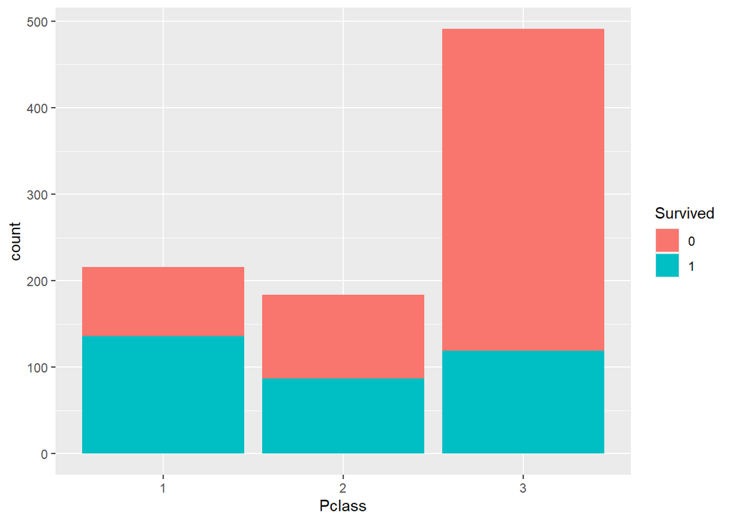

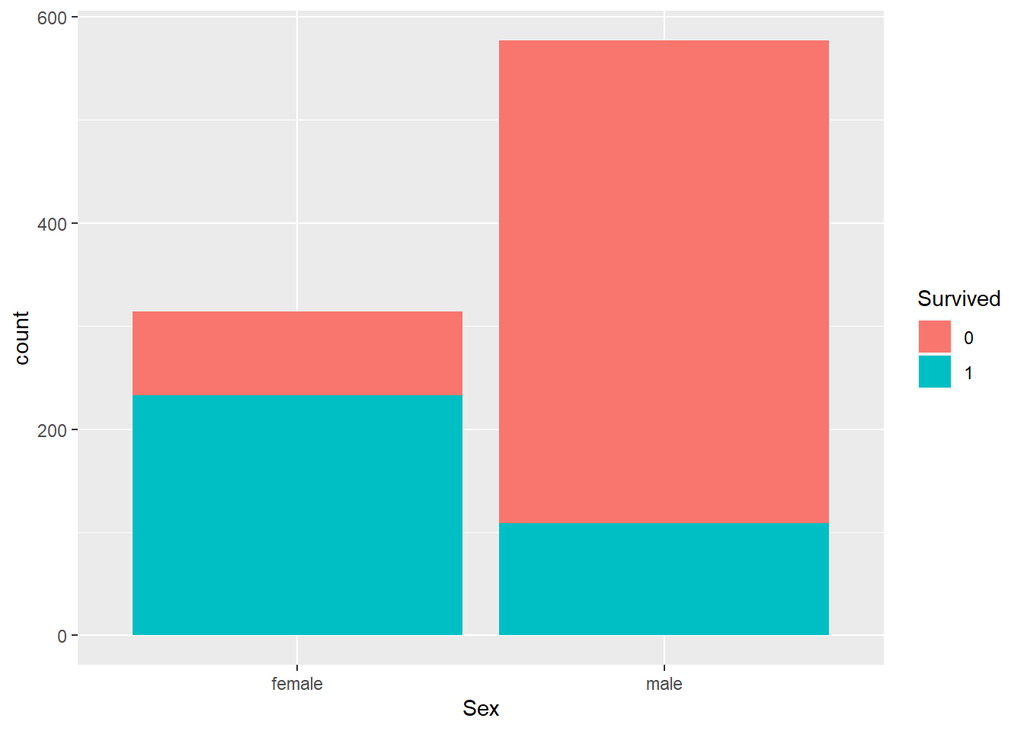

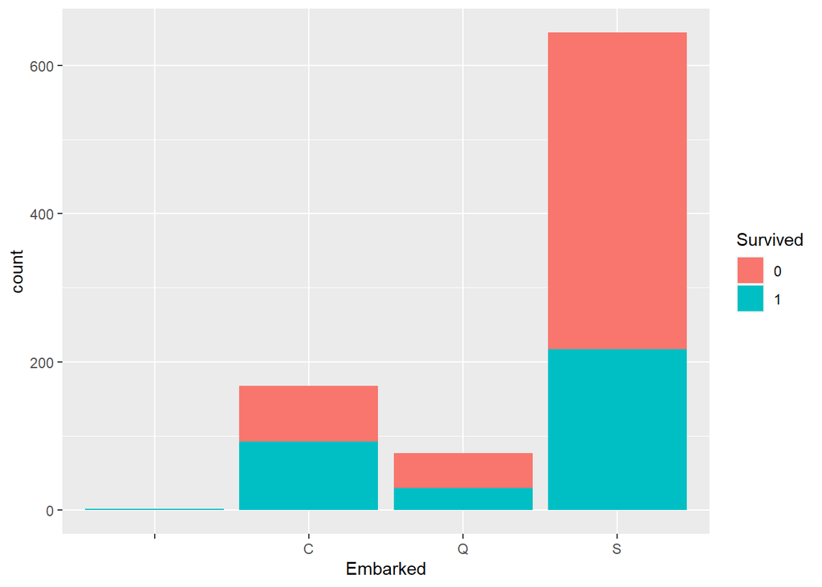

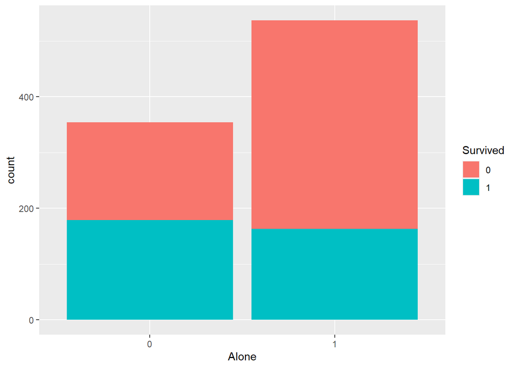

```r
for (var in categoricalVars) {
     print(ggplot(train) + geom_bar(aes_string(x=var,fill="Survived"),position="stack"))
}
```

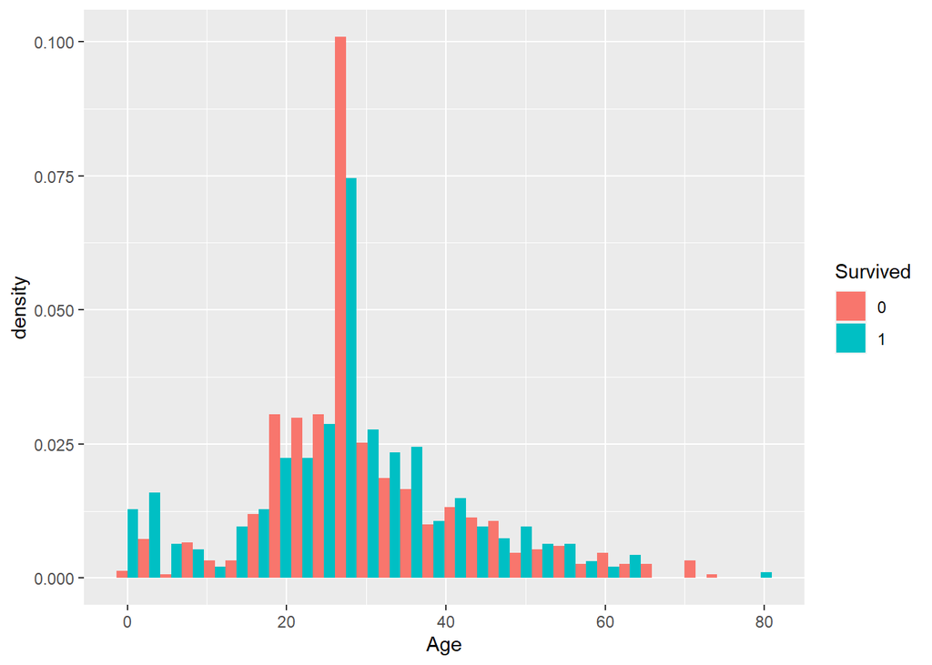

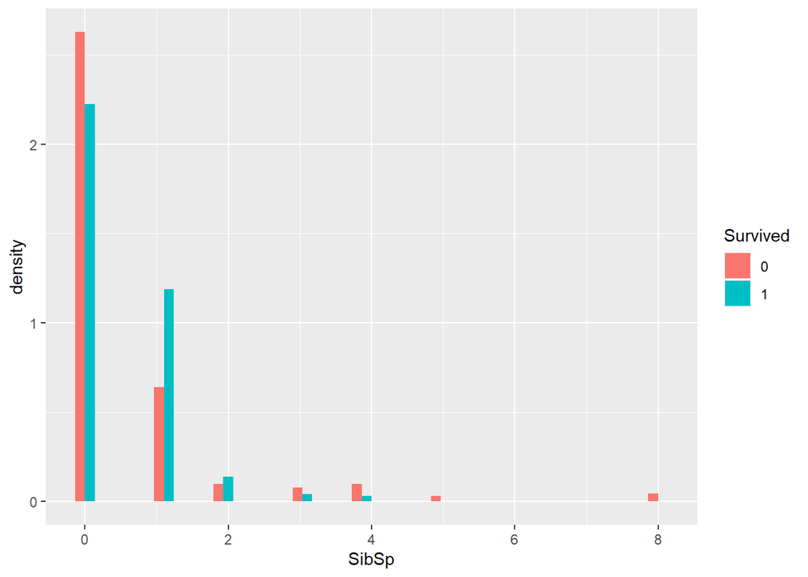

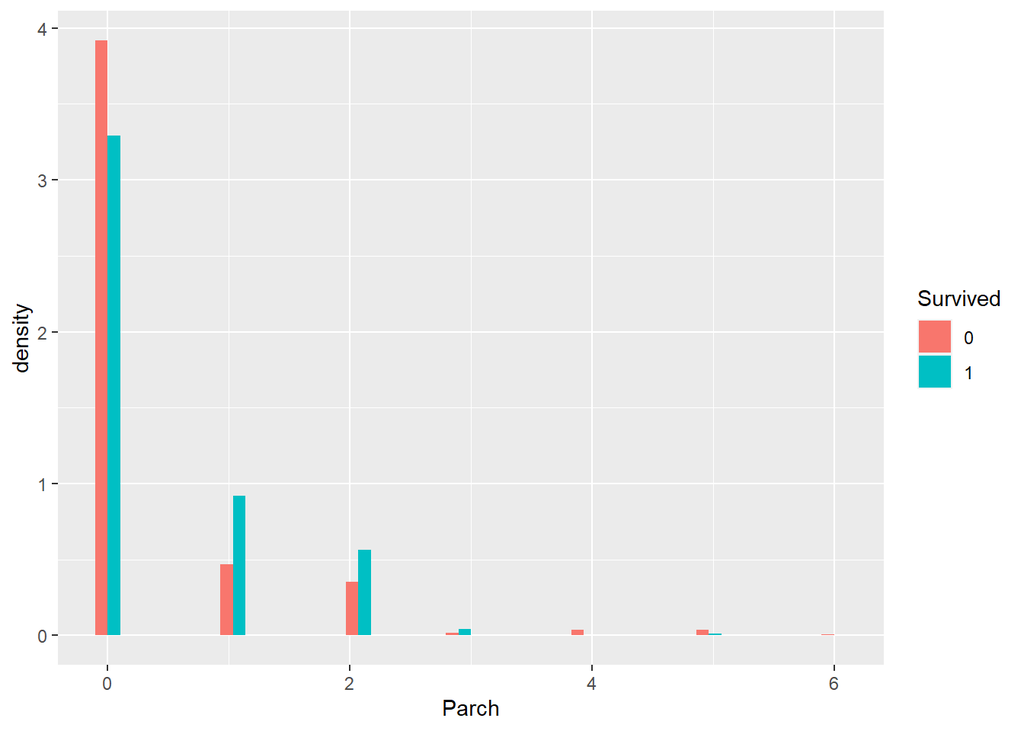

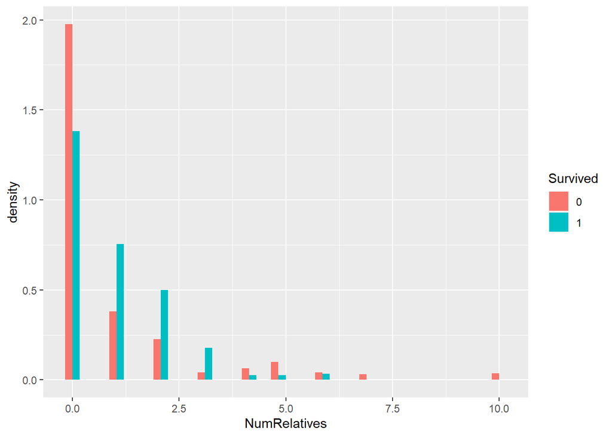

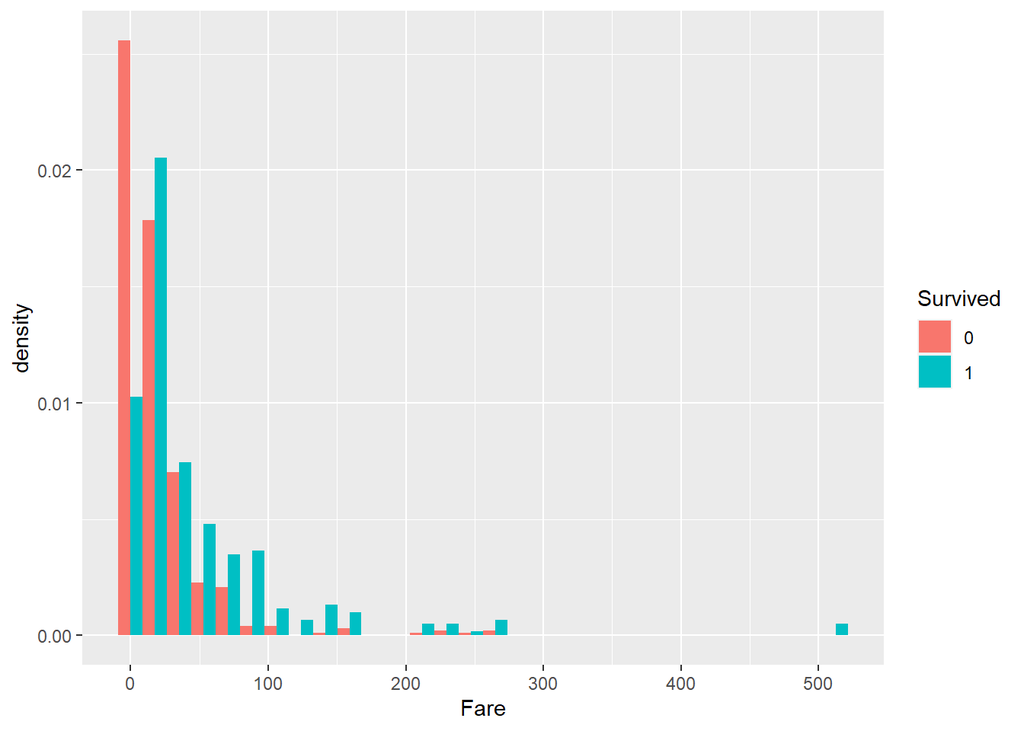

```r
for (var in continuousVars) {
     print(ggplot(train) + geom_histogram(aes_string(x=var,y="..density..",fill="Survived"),position="dodge"))
}
```

## Train Predictive Models

Different predictive models are trained using 10-fold cross validation: logistic regression (with stepwise selection), decision tree, linear discriminant analysis, k-nearest neighbors, naive Bayes, and random forest. Models are evaluated using accuracy. All of the models are competitive with each other, except k-nearest neighbors, producing accuracies near 0.80. The best performer on average is the random forest, but the figure below indicates that there is significant overlap with other classification models.

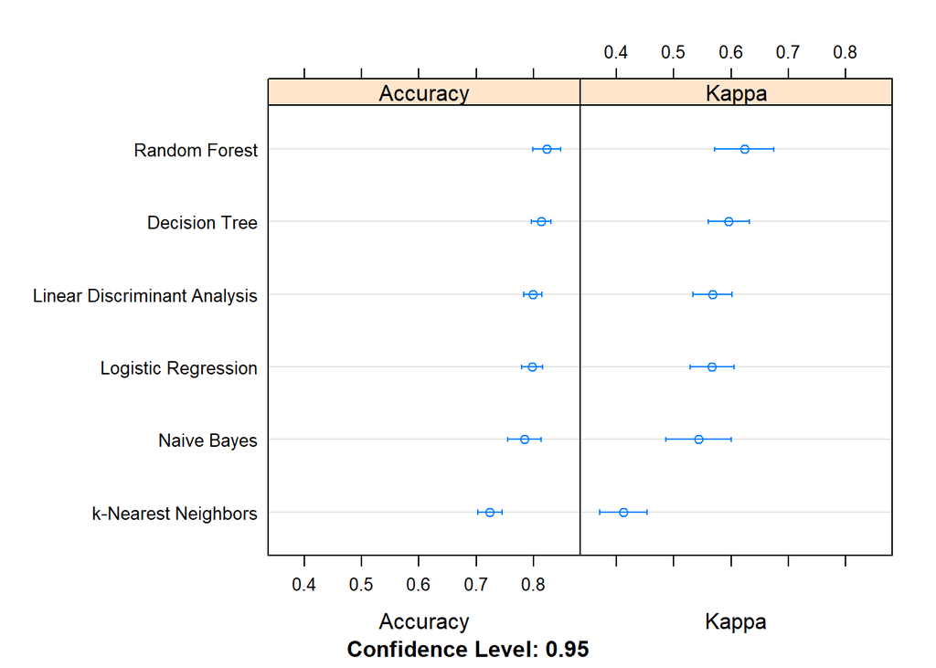

```r
# Remove variables in train that are not of interest (e.g., passenger name).
savelist = c(varlist,"Survived")
train = train[,..savelist]

# Set up 10-fold cross validation training.
tc = trainControl(method="cv", number=10)

modelList = list()
seed = 1234

set.seed(seed)
# Logistic regression
modelList[["glm"]] = train(Survived~., data=train, trControl=tc, method="glmStepAIC", family="binomial", trace=FALSE)

set.seed(seed)
# Decision tree
modelList[["rpart"]] = train(Survived~., data=train, trControl=tc, method="rpart")

set.seed(seed)
# Linear discriminant analysis
modelList[["lda"]] = train(Survived~., data=train, trControl=tc, method="lda")

set.seed(seed)
# k nearest neighbors
modelList[["knn"]] = train(Survived~., data=train, trControl=tc, method="knn")

set.seed(seed)
# Naive Bayes
modelList[["nb"]] = train(Survived~., data=train, trControl=tc, method="nb")

set.seed(seed)
# Random forest
modelList[["rf"]] = train(Survived~., data=train, trControl=tc, method="rf")

modelNames = c("Logistic Regression","Decision Tree","Linear Discriminant Analysis","k-Nearest Neighbors","Naive Bayes","Random Forest")
results = resamples(modelList, modelNames=modelNames)
dotplot(results)
```

## Predict Survivors in Test Sample

I select the random forest model and predict survivors from the test sample.

```r
test = fread("Data/test.csv")
test = convertToFactors(test)
# Impute NA ages with median from train set.
test[is.na(Age),Age:=medianAge]
# Impute NA fares with 0.
test[is.na(Fare),Fare:=0]
test = addVariables(test)
test[,PredSurvived:=predict(modelList[["rf"]],test)]
# Output predictions to file.
dir.create("Output", recursive=TRUE)
fwrite(test[,.(PassengerId,Survived=PredSurvived)], "Output/prediction.csv")
```